# Assigning positions in blocks of repeated elements in a vector: a performance comparison in R

Ricardo González-Gil

2024-12-13

## 1 Introduction

In many data manipulation tasks, it is often necessary to identify and label groups of consecutive, repeating elements within a vector. This need arises in a variety of applications, such as time series analysis, genomic sequence processing, and text data manipulation. Efficiently assigning positions to repeated values enables structured analysis and simplifies further computations.

For instance, given the following vector:

```r
x <- c(rep(0, 3), rep(1, 4), rep(0, 2), rep(1, 2), rep(0, 3), rep(1, 4), rep(0, 5))

print(x)
```

```
##  [1] 0 0 0 1 1 1 1 0 0 1 1 0 0 0 1 1 1 1 0 0 0 0 0
```

Our goal is to assign consecutive positions to blocks of “1s” while keeping 0s unchanged, resulting in:

**0 0 0 1 2 3 4 0 0 1 2 0 0 0 1 2 3 4 0 0 0 0 0**

This exercise explores multiple approaches to solving this problem and compares their efficiency in handling large vectors.

## 2 My approach

The solution revolves around:

1. Calculating a cumulative sum (cumsum) of the vector.
2. Isolating cumulative sums at positions corresponding to zeros (x != 1).
3. Interpolating these values to propagate them across zeros.
4. Subtracting the interpolated values from the original cumulative sum to derive the desired indices.

### 2.1 Cumulative sum

```r
cumsum_x <- cumsum(x)

print(cumsum_x)
```

```
##  [1]  0  0  0  1  2  3  4  4  4  5  6  6  6  6  7  8  9 10 10 10 10 10 10
```

This first step allows to assign consecutive positions to the “1s” when there is a block of them.

The mission after this simple first step is:

1. Keep as “0” where there is one.
2. Reset the count after each block of zeros

### 2.2 Filter cumulative sums for zero groups

For the first goal, we can create a vector that assigns to the each blocks of “0s”, the cumulative sum until the position of the block:

```r
cums_for_0 <- cumsum_x * (x != 1)

print(cums_for_0)
```

```
##  [1]  0  0  0  0  0  0  0  4  4  0  0  6  6  6  0  0  0  0 10 10 10 10 10
```

Subtracting these two cumulative sums, we get:

```r
cumsum_x - cums_for_0
```

```
##  [1]  0  0  0  1  2  3  4  0  0  5  6  0  0  0  7  8  9 10  0  0  0  0  0
```

This is closer to the desired solution. Now we just have to reset the count for each block of “1s” as previously indicated. For this, we’re going to use the interpolation function approx:

### 2.3 Interpolate values across zeros

```r
interpolated <- approx(
  x = which(cums_for_0 != 0),
  y = cums_for_0[which(cums_for_0 != 0)],
  xout = 1:length(cumsum_x),
  method = "constant",
  yleft = 0,
  rule = 2
)$y

print(interpolated)
```

```
##  [1]  0  0  0  0  0  0  0  4  4  4  4  6  6  6  6  6  6  6 10 10 10 10 10
```

Finally, let’s substract both vectors:

### 2.4 Calculate positional indices

```r
result <- cumsum_x - interpolated

print(result)
```

```
##  [1] 0 0 0 1 2 3 4 0 0 1 2 0 0 0 1 2 3 4 0 0 0 0 0
```

All steps combined:

```r
result <- cumsum(x) - approx(
  x = which(cumsum(x) * (x != 1) != 0),
  y = (cumsum(x) * (x != 1))[which(cumsum(x) * (x != 1) != 0)],
  xout = 1:length(cumsum(x)),
  method = "constant",
  yleft = 0,
  rule = 2
)$y

print(result)
```

```
##  [1] 0 0 0 1 2 3 4 0 0 1 2 0 0 0 1 2 3 4 0 0 0 0 0
```

### 2.5 Generalization of my solution

What if the “target element” being repeated isn’t 1, or the “in-between element” or “separator” isn’t 0? What if the elements are letters, words, or other types of values? And what if the separators are not just a single value, but multiple values, such as “A”, “B”, and “C”?

To address these scenarios, we can generalize the solution by creating a function that handles various data types, allowing you to specify the target element while treating all other elements as separators. This approach eliminates the need to explicitly define the separators, making the function robust even when there are multiple types of separators or other intervening elements. Additionally, the function provides flexibility to replace all non-target elements with a custom value if needed. Here’s how the generalized function works:

```r
assign_positions_general <- function(x, target, separator_value = 0) {
  # Convert to numeric mask for generality
  target_mask <- as.numeric(x == target)
  separator_mask <- as.numeric(x != target)

  # Cumulative sum calculation for the numeric mask
  cumsum_x <- cumsum(target_mask)

  # Isolate cumulative sums at positions where the separator is not present
  cums_no_separator <- cumsum_x * separator_mask

  # Interpolation: Add condition to handle empty cases
  if (all(cums_no_separator == 0)) {
    interpolated <- rep(0, length(cumsum_x))  # Default to all zeros
  } else {
    interpolated <- approx(
      x = which(cums_no_separator != 0),
      y = cums_no_separator[which(cums_no_separator != 0)],
      xout = seq_along(cumsum_x),
      method = "constant",
      yleft = 0,
      rule = 2
    )$y
  }

  # Calculate the result by subtracting interpolated values
  result <- cumsum_x - interpolated

  # Assign the separator value to elements that are not part of the target group
  result[!target_mask] <- separator_value

  return(result)
}
```

### 2.6 Example test cases

#### 2.6.1 Numeric data (single separator)

```r
x_num <- c(0, 0, 1, 1, 1, 0, 0, 1, 1, 0)
assign_positions_general(x_num, target = 1)
```

```
##  [1] 0 0 1 2 3 0 0 1 2 0
```

#### 2.6.2 Letters as data (single separator)

```r
x_abc <- c("A", "A", "B", "B", "A", "A", "B", "B", "B", "A")
assign_positions_general(x_abc, target = "B")
```

```
##  [1] 0 0 1 2 0 0 1 2 3 0
```

#### 2.6.3 Words as data (single separator)

```r
x_words <- c("apple", "apple", "banana", "banana", "apple", "apple", "banana", "banana", "banana")
assign_positions_general(x_words, target = "banana")
```

```
## [1] 0 0 1 2 0 0 1 2 3
```

#### 2.6.4 Numeric data with custom separator value

```r
x_num2 <- c(0, 0, 1, 1, 1, 0, 0, 1, 1, 0)
assign_positions_general(x_num2, target = 1, separator_value = -1)
```

```
##  [1] -1 -1  1  2  3 -1 -1  1  2 -1
```

#### 2.6.5 Multiple separator types

```r
x_abc_mult <- c("A", "A", "T", "C", "G", "G", "G", "A", "T", "G", "G")
assign_positions_general(x_abc_mult, target = "G")
```

```
##  [1] 0 0 0 0 1 2 3 0 0 1 2
```

#### 2.6.6 Mixed data types

```r
x_mix <- c(0, "A", 0, "B", 0, "B", "B", 0, "A", 1, 0)
assign_positions_general(x_mix, target = "B")
```

```
##  [1] 0 0 0 1 0 1 2 0 0 0 0
```

## 3 Alternative solutions

Let’s explore now other potential solutions:

### 3.1 rle (Run Length Encoding):

```r
rle_x <- rle(x)

indices_rle <- unlist(lapply(rle_x$lengths, seq_len)) * rep(rle_x$values == 1, rle_x$lengths)  # Generate positions for target values and set others to 0

print(indices_rle)
```

```
##  [1] 0 0 0 1 2 3 4 0 0 1 2 0 0 0 1 2 3 4 0 0 0 0 0
```

### 3.2 mutate and dplyr

```r
indices_dplyr <- data.frame(x = x) |>
  mutate(
    group = if_else(
      x == 1,
      ave(x, cumsum(x == 0), FUN = function(y) seq_along(y) - 1), # Assign positions for groups
      0 # Replace non-target values
    )
  )

print(indices_dplyr$group)
```

```
##  [1] 0 0 0 1 2 3 4 0 0 1 2 0 0 0 1 2 3 4 0 0 0 0 0
```

### 3.3 Loop

```r
indices_loop <- numeric(length(x)) # Initialize result vector
counter <- 0 # Initialize position counter

for (i in seq_along(x)) {
  if (i > 1 && x[i] != x[i - 1]) counter <- 0 # Reset counter for separators
  if (x[i] == 1) counter <- counter + 1 # Increment for target values
  indices_loop[i] <- if (x[i] == 1) counter else 0 # Assign positions
}

print(indices_loop)
```

```
##  [1] 0 0 0 1 2 3 4 0 0 1 2 0 0 0 1 2 3 4 0 0 0 0 0
```

### 3.4 Testing the alternative methods

Now, let’s create generalized functions:

```r
# rle solution
assign_positions_rle <- function(x, target, separator_value = 0) {
  rle_x <- rle(x) # Run-length encoding
  indices <- unlist(
    lapply(rle_x$lengths, seq_len) # Generate sequence positions within each run
  ) * rep(rle_x$values == target, rle_x$lengths) # Mask for target values

  indices[indices == 0] <- separator_value # Replace non-target values
  return(indices)
}

# dplyr solution
assign_positions_dplyr <- function(x, target, separator_value = 0) {
  # Handle the edge case when all elements are the target
  if (all(x == target)) {
    return(seq_along(x))
  }
  # Otherwise, apply sequential numbering within target groups
  data.frame(x = x) |>
    mutate(
      group = if_else(
        x == target,
        as.numeric(ave(x, cumsum(x != target), FUN = function(y) seq_along(y) - 1)),
        as.numeric(separator_value) # Replace non-target elements
      )
    ) |>
    pull(group) # Extract the vector output
}

# loop solution
assign_positions_loop <- function(x, target, separator_value = 0) {
  indices <- numeric(length(x)) # Initialize result vector
  counter <- 0 # Initialize position counter

  for (i in seq_along(x)) {
    if (i > 1 && x[i] != target) counter <- 0 # Reset counter at non-targets
    if (x[i] == target) counter <- counter + 1
    indices[i] <- if (x[i] == target) counter else separator_value
  }
  return(indices)
}
```

Testing these functions:

```r
# Test cases
test_cases <- list(
  x_num = list(
    vec = x_num,
    target = 1
  ),
  x_abc = list(
    vec = x_abc,
    target = "B"
  ),
  x_words = list(
    vec = x_words,
    target = "banana"
  ),
  x_num2 = list(
    vec = x_num2,
    target = 1,
    separator_value = -1
  ),
  x_abc_mult = list(
    vec = x_abc_mult,
    target = "G"
  ),
  x_mix = list(
    vec = x_mix,
    target = "B"
  )
)

# Helper function to run a method and collapse the result
run_method <- function(fun, vec, target, separator_value) {
  result <- fun(vec, target, separator_value)
  paste(result, collapse = " ")
}

# Replace map_dfr() with map() + list_rbind()
results_comparison <- map(names(test_cases), \(name) {
  tc <- test_cases[[name]]  # Extract test case
  separator_value <- ifelse("separator_value" %in% names(tc), tc$separator_value, 0)

  # List of methods to apply
  methods <- list(
    rle = assign_positions_rle,
    dplyr = assign_positions_dplyr,
    loop = assign_positions_loop
  )

  # Generate results for all methods
  map(names(methods), \(method_name) {
    tibble(
      test_case = name,
      method = method_name,
      result = run_method(methods[[method_name]], tc$vec, tc$target, separator_value)
    )
  }) |> list_rbind()  # Combine results for all methods into a single data frame
}) |> list_rbind()  # Combine results for all test cases

# Reference Expected Outputs
expected_outputs <- tibble(
  test_case = c(unique(results_comparison$test_case)),
  expected_outputs = c(
    "0 0 1 2 3 0 0 1 2 0",
    "0 0 1 2 0 0 1 2 3 0",
    "0 0 1 2 0 0 1 2 3",
    "-1 -1 1 2 3 -1 -1 1 2 -1",
    "0 0 0 0 1 2 3 0 0 1 2",
    "0 0 0 1 0 1 2 0 0 0 0"
  )
)

# Pivot the results_comparison table to wide format and checking whether
# all methods give the expected result
results_wide <-
  results_comparison |>
  pivot_wider(
    id_cols = test_case,
    names_from = method,
    values_from = result
  ) |>
  left_join(expected_outputs, by = "test_case") |>
  rowwise() |> # Perform row-wise operations
  mutate(
    all_methods_work = if_else(
      all(c_across(c(rle, dplyr, loop)) == expected_outputs),
      "Yes",
      "No"
    )
  ) |>
  ungroup() |> # Ungroup after row-wise operation
  select(test_case, expected_outputs, all_methods_work)

# Print results
print(results_wide)
```

```
## # A tibble: 6 × 3
##   test_case  expected_outputs         all_methods_work
##   <chr>      <chr>                    <chr>
## 1 x_num      0 0 1 2 3 0 0 1 2 0      Yes
## 2 x_abc      0 0 1 2 0 0 1 2 3 0      Yes
## 3 x_words    0 0 1 2 0 0 1 2 3        Yes
## 4 x_num2     -1 -1 1 2 3 -1 -1 1 2 -1 Yes
## 5 x_abc_mult 0 0 0 0 1 2 3 0 0 1 2    Yes
## 6 x_mix      0 0 0 1 0 1 2 0 0 0 0    Yes
```

## 4 Benchmarking

In this section, we compare the execution speed of the different approaches.

To ensure reproducibility, we generate test vectors with controlled sequences of “0s” and “1s”:

```r
set.seed(123) # Set seed for reproducibility

# Optimized function to generate intercalated sequences of 0s and 1s with exact lengths
generate_test_vector <- function(total_length) {
  # Generate random lengths
  lengths_val <- sample(1:25, size = total_length, replace = TRUE)

  # Calculate cumulative sum to determine valid lengths
  cumulative_lengths <- cumsum(lengths_val)
  lengths_val <- lengths_val[cumulative_lengths <= total_length]

  # Adjust the last length to ensure exact total length
  lengths_val[length(lengths_val)] <-
    total_length - sum(lengths_val[-length(lengths_val)])

  # Alternate between 0 and 1
  values <- rep(c(0, 1), length.out = length(lengths_val))

  # Generate the final intercalated sequence
  map2(values, lengths_val, rep) |> list_c()
}

# Generate test vectors with exact lengths
vector_lengths <- c(1e3, 1e4, 1e5, 1e6) # Define vector lengths
test_vectors <- map(vector_lengths, generate_test_vector)

# Set names for the test vectors based on their lengths
names(test_vectors) <- as.character(vector_lengths)

# Check the generated test vectors
str(test_vectors)
```

```
## List of 4
##  $ 1000 : num [1:1000] 0 0 0 0 0 0 0 0 0 0 ...
##  $ 10000: num [1:10000] 0 0 0 0 0 0 0 0 0 0 ...
##  $ 1e+05: num [1:100000] 0 0 0 0 0 0 0 0 0 0 ...
##  $ 1e+06: num [1:1000000] 0 0 0 0 0 0 0 0 0 0 ...
```

We use the `microbenchmark` package to evaluate execution time for each method:

```r
benchmark_assign_positions <- function(test_vectors, target = 1) {
  # Benchmark for each vector size
  map_dfr(
    names(test_vectors), # Iterate over the names of the test vectors
    \(name) {
      vector <- test_vectors[[name]] # Extract the test vector
      microbenchmark(
        rle = assign_positions_rle(vector, target),
        dplyr = assign_positions_dplyr(vector, target),
        loop = assign_positions_loop(vector, target),
        general = assign_positions_general(vector, target),
        times = 40 # Number of repetitions
      ) |>
        as_tibble() |>
        mutate(vector_length = as.numeric(name)) # Add vector length as a column
    }
  )
}

# Run benchmarking
benchmark_results <-
  benchmark_assign_positions(test_vectors, target = 1) |>
  rename(method = expr) |>
  arrange(method, vector_length) |>
  relocate(vector_length, .before = time)
```

We can now visually inspect the performance of the 4 methods:

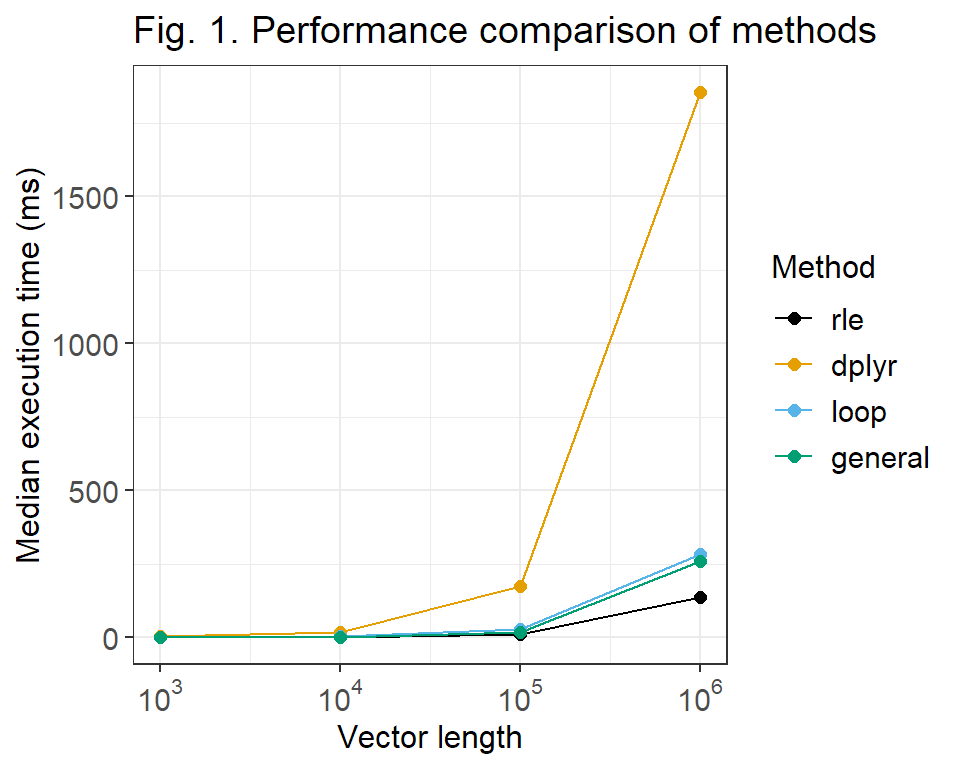

```r
# Showing the results
# Color palette for color blindness
colorBlindBlack8  <- c("#000000", "#E69F00", "#56B4E9", "#009E73", "#F0E442", "#0072B2", "#D55E00", "#CC79A7")

# The plot
benchmark_results |>
  group_by(method, vector_length) |>
  summarise(med_t = median(time) / 1e6, .groups = "drop") |>
  ggplot(aes(vector_length, med_t, color = method)) +
  geom_line() +
  geom_point(size = 2) +
  scale_x_log10(
    label = trans_format("log10", math_format(10^.x))
  ) +
  scale_color_manual(values = colorBlindBlack8[1:4]) +
  labs(
    x = "Vector length",
    y = "Median execution time (ms)",
    title = "Fig. 1. Performance comparison of methods",
    color = "Method"
  ) +
  theme_bw() +
  theme(
    text = element_text(size = 14),
    title = element_text(size = 12)
  )
```

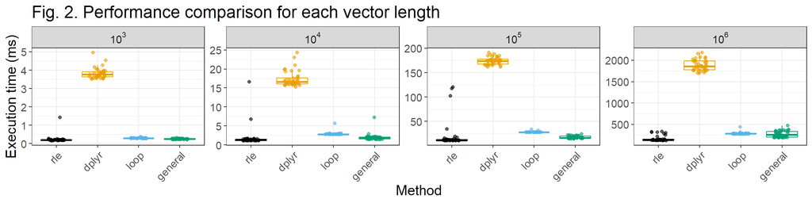

```r
benchmark_results |>
  group_by(method, vector_length) |>
  # mutate(vector_length_lab = paste())
  ggplot(aes(x = method, y = time  / 1e6, color = method)) +
  geom_boxplot(outlier.shape = NA, alpha = 0.7) +
  geom_jitter(width = 0.2, alpha = 0.6, size = 1.5) +
  scale_color_manual(values = colorBlindBlack8[1:4], guide = "none") +
  facet_wrap(
    ~ vector_length,
    nrow = 1,
    scales = "free",
    labeller = as_labeller(
      ~ paste0("10^", log10(as.numeric(.))),
      default = label_parsed
    )
  ) +
  labs(
    x = "Method",
    y = "Execution time (ms)",
    title = "Fig. 2. Performance comparison for each vector length"
  ) +
  theme_bw() +
  theme(
    axis.text.x = element_text(angle = 45, hjust = 1),
    text = element_text(size = 14),
    title = element_text(size = 15)
  )
```

## 5 Results and discussion:

The performance comparison, shown in Figs. 1 and 2, highlights the efficiency differences between the four methods.

### 5.1 Key observations:

- The **rle** method consistently outperforms the others, demonstrating its efficiency in processing repeated sequences.
- The **general** and **loop** methods show comparable performance, with **general** surpassing **loop** for larger vectors.
- The **dplyr** approach is the slowest, particularly for long vectors, likely due to the overhead introduced by `mutate()` and `ave()` operations. Variations of this method could potentially improve its performance.

The table below summarizes the advantages and disadvantages of each method:

| Method | Advantages | Disadvantages |
| --- | --- | --- |
| **rle** | Fastest method, leverages R’s built-in `rle()` for efficient computation | Less intuitive for some users |
| **general** | Well-structured approach, leverages cumulative sum and interpolation | Slower than **rle**, especially for large inputs |
| **loop** | Simple logic and easy to understand | Slightly slower than **general** |
| **dplyr** | Readable, integrates well into `tidyverse` workflows | Slowest method, performance drops for large vectors |

## 6 Conclusions

This exercise examined four different solutions for assigning positions within repeated element blocks, demonstrating that multiple valid approaches exist, each with distinct trade-offs.

The **rle-based** solution is the most efficient, making it the recommended choice when performance is critical. However, the selection of a method ultimately depends on the specific problem context—whether prioritizing speed, interpretability, or adaptability. Additionally, variations of these methods or entirely different implementations not explored in this analysis may offer further optimizations.

These findings emphasize the importance of benchmarking before selecting a method for large-scale data processing tasks, ensuring that the chosen approach aligns with the goals and constraints of the analysis.

## 7 Acknowledgements

I would like to thank Fernando González Taboada and Paula Izquierdo for their valuable insights and inspiration in this exercise.